# Cours 7 : `scikit-learn`

**Loïc Grobol** lgrobol@parisnanterre.fr

2021-10-05

```python
from IPython.display import display
```

## `scikit-learn` ?

[`scikit-learn`](https://scikit-learn.org/stable/index.html).

`scikit-learn` est une bibliothèque Python dédiée à l'apprentissage artificiel. Ce package est développé sur licence libre. Il y a une forte proportion de français parmi les développeurs, le projet est soutenu par l'INRIA notamment.

`scikit-learn` repose sur NumPy et SciPy. Il est écrit en Python et Cython. Il s'interface très bien avec `matplotlib`, `plotly` ou `pandas`. C'est devenu un incontournable du *machine learning* et de la *datascience* en Python.

Dans ce notebook nous nous limiterons à la classification, une partie seulement du package [scikit-learn](https://scikit-learn.org/stable/index.html).

La classification est souvent utilisée en TAL, par exemple dans les tâches d'analyse de sentiment, de détection d'émotion ou l'identification de la langue.

On va faire de l'apprentissage *supervisé*, vous connaissez la chanson : l'idée est d'apprendre un modèle à partir de données étiquetées et de prédire la bonne étiquette pour une donnée inconnue du modèle.

Dit autrement, on a un échantillon d'entraînement composé de $n$ couples $Z_{i}=(X_{i}, Y_{i}), i=1...n$ où les $X_{i}$ sont les inputs avec plusieurs traits et les $Y_{i}$ seront les outputs, les catégories à prédire.

L'objectif du problème d'apprentissage est de trouver une fonction $g:X→Y$ de prédiction, qui minimise les erreurs de prédiction.

`scikit-learn` offre beaucoup d'algorithmes d'apprentissage. Vous en trouverez un aperçu sur [cette carte](https://scikit-learn.org/stable/tutorial/machine_learning_map/index.html) et sur ces listes : [supervisé](https://scikit-learn.org/stable/supervised_learning.html) / [non supervisé](https://scikit-learn.org/stable/unsupervised_learning.html).

Mais `scikit-learn` offre également les outils pour mener à bien les étapes d'une tâche de d'apprentissage :

- Manipuler les données, constituer un jeu de données d'entraînement et de test
- Entraînement du modèle
- Évaluation
- Optimisation des hyperparamètres

```python
%pip install -U scikit-learn
```

## Un premier exemple

### Les données

C'est la clé de voute du *machine learning*, vous le savez n'est-ce pas ? Nous allons travailler avec un des jeux de données fourni par scikit-learn : [le jeu de données de reconnaissance des vins](https://scikit-learn.org/stable/datasets/toy_dataset.html#wine-recognition-dataset)

C'est plus facile pour commencer parce que les données sont déjà nettoyées et organisées.

```python
from sklearn import datasets
wine = datasets.load_wine()
type(wine)
```

```
sklearn.utils.Bunch
```

(La recommandation des développeureuses de `scikit-learn` est d'importer uniquement les parties qui nous intéresse plutôt que tout le package. Notez aussi le nom `sklearn` pour l'import.)

Ces jeux de données sont des objets `sklearn.utils.Bunch`. Organisés un peu comme des dictionnaires Python, ces objets contiennent :

- `data` : array NumPy à deux dimensions d'échantillons de données (n_samples * n_features), les inputs, les X
- `target` : les variables à prédire, les catégories des échantillons si vous voulez, les outputs, les y
- `feature_names`
- `target_names`

```python
print(wine.DESCR)
```

```
.. _wine_dataset:

Wine recognition dataset
------------------------

**Data Set Characteristics:**

    :Number of Instances: 178 (50 in each of three classes)
    :Number of Attributes: 13 numeric, predictive attributes and the class
    :Attribute Information:
 		- Alcohol
 		- Malic acid
 		- Ash
		- Alcalinity of ash
 		- Magnesium
		- Total phenols
 		- Flavanoids
 		- Nonflavanoid phenols
 		- Proanthocyanins
		- Color intensity
 		- Hue
 		- OD280/OD315 of diluted wines
 		- Proline

    - class:
            - class_0
            - class_1
            - class_2

    :Summary Statistics:

    ============================= ==== ===== ======= =====
                                   Min   Max   Mean     SD
    ============================= ==== ===== ======= =====
    Alcohol:                      11.0  14.8    13.0   0.8
    Malic Acid:                   0.74  5.80    2.34  1.12
    Ash:                          1.36  3.23    2.36  0.27
    Alcalinity of Ash:            10.6  30.0    19.5   3.3
    Magnesium:                    70.0 162.0    99.7  14.3
    Total Phenols:                0.98  3.88    2.29  0.63
```

[output cut: 40 more lines]

```
  Tech. Rep. no. 92-02, (1992), Dept. of Computer Science and Dept. of
  Mathematics and Statistics, James Cook University of North Queensland.
  (Also submitted to Technometrics).

  The data was used with many others for comparing various
  classifiers. The classes are separable, though only RDA
  has achieved 100% correct classification.
  (RDA : 100%, QDA 99.4%, LDA 98.9%, 1NN 96.1% (z-transformed data))
  (All results using the leave-one-out technique)

  (2) S. Aeberhard, D. Coomans and O. de Vel,
  "THE CLASSIFICATION PERFORMANCE OF RDA"
  Tech. Rep. no. 92-01, (1992), Dept. of Computer Science and Dept. of
  Mathematics and Statistics, James Cook University of North Queensland.
  (Also submitted to Journal of Chemometrics).
```

```python
wine.feature_names
```

```
['alcohol',
 'malic_acid',
 'ash',
 'alcalinity_of_ash',
 'magnesium',
 'total_phenols',
 'flavanoids',
 'nonflavanoid_phenols',
 'proanthocyanins',
 'color_intensity',
 'hue',
 'od280/od315_of_diluted_wines',
 'proline']
```

Si on a installé `pandas`

```python
%pip install -U pandas
```

[output not shown]

On peut convertir ces données en `Dataframe` pandas si on veut.

```python
import pandas as pd

df = pd.DataFrame(data=wine.data,columns=wine.feature_names)
df['target']=wine.target
df.head()
```

|  | alcohol | malic_acid | ash | alcalinity_of_ash | magnesium | total_phenols | flavanoids | nonflavanoid_phenols | proanthocyanins | color_intensity | hue | od280/od315_of_diluted_wines | proline | target |
| --- | --- | --- | --- | --- | --- | --- | --- | --- | --- | --- | --- | --- | --- | --- |
| 0 | 14.23 | 1.71 | 2.43 | 15.6 | 127.0 | 2.80 | 3.06 | 0.28 | 2.29 | 5.64 | 1.04 | 3.92 | 1065.0 | 0 |
| 1 | 13.20 | 1.78 | 2.14 | 11.2 | 100.0 | 2.65 | 2.76 | 0.26 | 1.28 | 4.38 | 1.05 | 3.40 | 1050.0 | 0 |
| 2 | 13.16 | 2.36 | 2.67 | 18.6 | 101.0 | 2.80 | 3.24 | 0.30 | 2.81 | 5.68 | 1.03 | 3.17 | 1185.0 | 0 |
| 3 | 14.37 | 1.95 | 2.50 | 16.8 | 113.0 | 3.85 | 3.49 | 0.24 | 2.18 | 7.80 | 0.86 | 3.45 | 1480.0 | 0 |
| 4 | 13.24 | 2.59 | 2.87 | 21.0 | 118.0 | 2.80 | 2.69 | 0.39 | 1.82 | 4.32 | 1.04 | 2.93 | 735.0 | 0 |

Mais l'essentiel est de retrouver nos inputs X et outputs y nécessaires à l'apprentissage.

```python
X_wine, y_wine = wine.data, wine.target
```

Vous pouvez séparer les données en train et test facilement à l'aide de `sklearn.model_selection.train_test_split` ( voir la [doc](https://scikit-learn.org/stable/modules/generated/sklearn.model_selection.train_test_split.html#sklearn.model_selection.train_test_split))

```python
from sklearn.model_selection import train_test_split
X_train, X_test, y_train, y_test = train_test_split(X_wine, y_wine, test_size=0.3)
y_train
```

```
array([1, 2, 1, 2, 0, 0, 0, 2, 1, 0, 1, 0, 1, 1, 1, 0, 0, 0, 1, 1, 1, 0,
       2, 2, 0, 1, 0, 2, 2, 1, 1, 1, 0, 0, 2, 1, 1, 2, 1, 1, 2, 1, 0, 0,
       2, 2, 2, 0, 1, 1, 2, 0, 0, 2, 2, 0, 2, 2, 2, 1, 0, 1, 2, 1, 1, 0,
       2, 1, 0, 0, 0, 1, 1, 2, 1, 1, 0, 1, 1, 2, 1, 0, 1, 0, 0, 0, 1, 1,
       2, 0, 1, 2, 1, 1, 1, 2, 1, 1, 2, 1, 0, 1, 0, 1, 0, 2, 2, 0, 2, 0,
       1, 1, 1, 0, 0, 2, 1, 1, 2, 0, 0, 0, 0, 0])
```

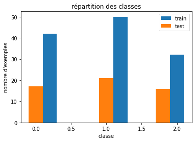

```python
import matplotlib.pyplot as plt
%matplotlib inline

plt.hist(y_train, align="right", label="train")
plt.hist(y_test, align="left", label="test")
plt.legend()
plt.xlabel("classe")
plt.ylabel("nombre d'exemples")
plt.title("répartition des classes")
plt.show()
```

Il ne faut pas hésiter à recourir à des représentations graphiques quand vous manipulez les données. Ici on voit que la répartition des classes à prédire n'est pas homogène pour les données de test.  
On peut y remédier en utilisant le paramètre `stratify`, qui fait appel à [`StratifiedShuffleSplit`](https://scikit-learn.org/stable/modules/generated/sklearn.model_selection.StratifiedShuffleSplit.html) pour préserver la même répartition des classes dans le train et dans le test.

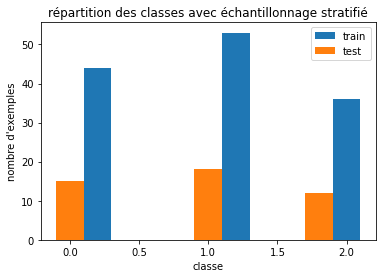

```python
X_train, X_test, y_train, y_test = train_test_split(X_wine, y_wine, test_size=0.25, stratify=y_wine)
plt.hist(y_train, align="right", label="train")
plt.hist(y_test, align="left", label="test")
plt.legend()
plt.xlabel("classe")
plt.ylabel("nombre d'exemples")
plt.title("répartition des classes avec échantillonnage stratifié")
plt.show()
```

## Entraînement

L'étape suivante est de choisir un algorithme (un *estimator*), de l'entraîner sur nos données train (avec la fonction `fit()`) puis de faire la prédiction (avec la fonction `predict`).  
Quelque soit l'algo choisi vous allez retrouver les fonctions `fit` et `predict`. Ce qui changera ce seront les paramètres à passer au constructeur de la classe de l'algo. Votre travail portera sur le choix de ces paramètres.

Exemple un peu bateau avec une méthode de type SVM.

```python
from sklearn.svm import SVC
clf = SVC(C=1, kernel="linear")
clf.fit(X_train, y_train)
```

```
SVC(C=1, kernel='linear')
```

```python
clf.predict(X_test)
```

```
array([1, 0, 0, 0, 0, 2, 2, 1, 2, 1, 0, 0, 1, 0, 0, 2, 2, 2, 2, 1, 1, 0,
       1, 1, 0, 1, 1, 1, 1, 1, 2, 1, 0, 2, 2, 0, 0, 0, 1, 2, 1, 2, 2, 1,
       1])
```

## Évaluation

On fait l'évaluation en confrontant les prédictions sur les `X_test` et les `y_test`. La fonction `score` nous donne l'exactitude (*accuracy*) moyenne du modèle.

```python
clf.score(X_test, y_test)
```

```
0.9555555555555556
```

Pour la classification il existe une classe bien pratique : `sklearn.metrics.classification_report`

```python
from sklearn.metrics import classification_report

y_pred = clf.predict(X_test)
print(classification_report(y_test, y_pred))
```

```
              precision    recall  f1-score   support

           0       1.00      0.93      0.97        15
           1       0.94      0.94      0.94        18
           2       0.92      1.00      0.96        12

    accuracy                           0.96        45
   macro avg       0.96      0.96      0.96        45
weighted avg       0.96      0.96      0.96        45
```

## ✍️ Exo ✍️

1. Essayez un autre algo de classification (Un SVM polynomial par exemple) et comparez les résultats.
2. Sur ce même algo, refaites une partition train/test et comparez l'évaluation avec les résultats précédents.

## Validation croisée

Pour améliorer la robustesse de l'évaluation on va utiliser la validation croisé (*cross-validation*). `scikit-learn` a des classes pour ça.

```python
from sklearn.model_selection import cross_validate, cross_val_score
print(cross_validate(SVC(C=1, kernel="linear"), X_wine, y_wine)) # infos d'accuracy mais aussi de temps
print(cross_val_score(SVC(C=1, kernel="linear"), X_wine, y_wine)) # uniquement accuracy
```

```
{'fit_time': array([0.07522917, 0.07297969, 0.09147239, 0.08495045, 0.07556343]), 'score_time': array([0.0005424 , 0.00056291, 0.00059628, 0.00060034, 0.00067973]), 'test_score': array([0.88888889, 0.94444444, 0.97222222, 1.        , 1.        ])}
[0.88888889 0.94444444 0.97222222 1.         1.        ]
```

## Optimisation des hyperparamètres

L'optimisation des hyperparamètres est la dernière étape. Ici encore `scikit-learn` nous permet de le faire de manière simple et efficace. Nous utiliserons `sklearn.model_selection.GridSearchCV` qui fait une recherche exhaustive sur tous les paramètres donnés au constructeur. Cette classe utilise aussi la validation croisée.

```python
from sklearn.model_selection import GridSearchCV

param_grid =  {'C': [0.1, 0.5, 1, 10, 100, 1000], 'kernel':['rbf','linear']}
grid = GridSearchCV(SVC(), param_grid, cv = 5, scoring = 'accuracy')
estimator = grid.fit(X_wine, y_wine)
estimator.cv_results_
```

```
{'mean_fit_time': array([0.00176625, 0.06031365, 0.00139775, 0.0851531 , 0.00140343,
        0.07716694, 0.00125322, 0.1834548 , 0.00150356, 0.18068643,
        0.00220256, 0.18568411]),
 'std_fit_time': array([5.34796629e-05, 2.71933680e-02, 7.22548500e-05, 3.14957923e-02,
        6.93253995e-05, 6.48216539e-03, 2.49069717e-05, 5.29102937e-02,
        5.57596989e-05, 5.25686982e-02, 2.76293967e-04, 4.89797790e-02]),
 'mean_score_time': array([0.00064254, 0.00047584, 0.00062671, 0.00047278, 0.00059209,
        0.00049682, 0.00055556, 0.00057721, 0.0006536 , 0.00063095,
        0.00049171, 0.00060482]),
 'std_score_time': array([5.21440564e-05, 9.69335471e-05, 6.28214814e-05, 7.33418333e-05,
        3.97973674e-05, 9.20270267e-05, 2.81961194e-05, 9.68311751e-05,
        4.87164715e-05, 5.72185913e-05, 3.55563884e-05, 3.81771803e-05]),
 'param_C': masked_array(data=[0.1, 0.1, 0.5, 0.5, 1, 1, 10, 10, 100, 100, 1000, 1000],
              mask=[False, False, False, False, False, False, False, False,
                    False, False, False, False],
        fill_value='?',
             dtype=object),
 'param_kernel': masked_array(data=['rbf', 'linear', 'rbf', 'linear', 'rbf', 'linear',
                    'rbf', 'linear', 'rbf', 'linear', 'rbf', 'linear'],
              mask=[False, False, False, False, False, False, False, False,
                    False, False, False, False],
        fill_value='?',
             dtype=object),
 'params': [{'C': 0.1, 'kernel': 'rbf'},
  {'C': 0.1, 'kernel': 'linear'},
  {'C': 0.5, 'kernel': 'rbf'},
  {'C': 0.5, 'kernel': 'linear'},
  {'C': 1, 'kernel': 'rbf'},
  {'C': 1, 'kernel': 'linear'},
  {'C': 10, 'kernel': 'rbf'},
  {'C': 10, 'kernel': 'linear'},
  {'C': 100, 'kernel': 'rbf'},
  {'C': 100, 'kernel': 'linear'},
  {'C': 1000, 'kernel': 'rbf'},
  {'C': 1000, 'kernel': 'linear'}],
 'split0_test_score': array([0.66666667, 0.91666667, 0.61111111, 0.94444444, 0.63888889,
        0.88888889, 0.75      , 0.88888889, 0.75      , 0.88888889,
        0.83333333, 0.88888889]),
 'split1_test_score': array([0.61111111, 0.91666667, 0.66666667, 0.94444444, 0.61111111,
        0.94444444, 0.66666667, 0.97222222, 0.69444444, 0.97222222,
        0.86111111, 0.97222222]),
 'split2_test_score': array([0.69444444, 0.97222222, 0.63888889, 0.94444444, 0.63888889,
        0.97222222, 0.66666667, 0.94444444, 0.69444444, 0.94444444,
        0.94444444, 0.94444444]),
 'split3_test_score': array([0.65714286, 1.        , 0.65714286, 1.        , 0.68571429,
        1.        , 0.71428571, 1.        , 0.74285714, 1.        ,
        0.91428571, 1.        ]),
 'split4_test_score': array([0.74285714, 1.        , 0.74285714, 1.        , 0.74285714,
        1.        , 0.8       , 1.        , 0.82857143, 1.        ,
        0.91428571, 1.        ]),
 'mean_test_score': array([0.67444444, 0.96111111, 0.66333333, 0.96666667, 0.66349206,
        0.96111111, 0.71952381, 0.96111111, 0.74206349, 0.96111111,
        0.89349206, 0.96111111]),
 'std_test_score': array([0.043477  , 0.03767961, 0.04404126, 0.02721655, 0.04636171,
        0.04157397, 0.0510302 , 0.04157397, 0.04915768, 0.04157397,
        0.04031996, 0.04157397]),
 'rank_test_score': array([10,  2, 12,  1, 11,  2,  9,  2,  8,  2,  7,  2], dtype=int32)}
```

```python
df = pd.DataFrame(estimator.cv_results_)
df.sort_values('rank_test_score')
```

|  | mean_fit_time | std_fit_time | mean_score_time | std_score_time | param_C | param_kernel | params | split0_test_score | split1_test_score | split2_test_score | split3_test_score | split4_test_score | mean_test_score | std_test_score | rank_test_score |
| --- | --- | --- | --- | --- | --- | --- | --- | --- | --- | --- | --- | --- | --- | --- | --- |
| 3 | 0.085153 | 0.031496 | 0.000473 | 0.000073 | 0.5 | linear | {'C': 0.5, 'kernel': 'linear'} | 0.944444 | 0.944444 | 0.944444 | 1.000000 | 1.000000 | 0.966667 | 0.027217 | 1 |
| 1 | 0.060314 | 0.027193 | 0.000476 | 0.000097 | 0.1 | linear | {'C': 0.1, 'kernel': 'linear'} | 0.916667 | 0.916667 | 0.972222 | 1.000000 | 1.000000 | 0.961111 | 0.037680 | 2 |
| 5 | 0.077167 | 0.006482 | 0.000497 | 0.000092 | 1 | linear | {'C': 1, 'kernel': 'linear'} | 0.888889 | 0.944444 | 0.972222 | 1.000000 | 1.000000 | 0.961111 | 0.041574 | 2 |
| 7 | 0.183455 | 0.052910 | 0.000577 | 0.000097 | 10 | linear | {'C': 10, 'kernel': 'linear'} | 0.888889 | 0.972222 | 0.944444 | 1.000000 | 1.000000 | 0.961111 | 0.041574 | 2 |
| 9 | 0.180686 | 0.052569 | 0.000631 | 0.000057 | 100 | linear | {'C': 100, 'kernel': 'linear'} | 0.888889 | 0.972222 | 0.944444 | 1.000000 | 1.000000 | 0.961111 | 0.041574 | 2 |
| 11 | 0.185684 | 0.048980 | 0.000605 | 0.000038 | 1000 | linear | {'C': 1000, 'kernel': 'linear'} | 0.888889 | 0.972222 | 0.944444 | 1.000000 | 1.000000 | 0.961111 | 0.041574 | 2 |
| 10 | 0.002203 | 0.000276 | 0.000492 | 0.000036 | 1000 | rbf | {'C': 1000, 'kernel': 'rbf'} | 0.833333 | 0.861111 | 0.944444 | 0.914286 | 0.914286 | 0.893492 | 0.040320 | 7 |
| 8 | 0.001504 | 0.000056 | 0.000654 | 0.000049 | 100 | rbf | {'C': 100, 'kernel': 'rbf'} | 0.750000 | 0.694444 | 0.694444 | 0.742857 | 0.828571 | 0.742063 | 0.049158 | 8 |
| 6 | 0.001253 | 0.000025 | 0.000556 | 0.000028 | 10 | rbf | {'C': 10, 'kernel': 'rbf'} | 0.750000 | 0.666667 | 0.666667 | 0.714286 | 0.800000 | 0.719524 | 0.051030 | 9 |
| 0 | 0.001766 | 0.000053 | 0.000643 | 0.000052 | 0.1 | rbf | {'C': 0.1, 'kernel': 'rbf'} | 0.666667 | 0.611111 | 0.694444 | 0.657143 | 0.742857 | 0.674444 | 0.043477 | 10 |
| 4 | 0.001403 | 0.000069 | 0.000592 | 0.000040 | 1 | rbf | {'C': 1, 'kernel': 'rbf'} | 0.638889 | 0.611111 | 0.638889 | 0.685714 | 0.742857 | 0.663492 | 0.046362 | 11 |
| 2 | 0.001398 | 0.000072 | 0.000627 | 0.000063 | 0.5 | rbf | {'C': 0.5, 'kernel': 'rbf'} | 0.611111 | 0.666667 | 0.638889 | 0.657143 | 0.742857 | 0.663333 | 0.044041 | 12 |

## Classification de textes

Le [dataset 20 newsgroups](https://scikit-learn.org/stable/auto_examples/text/plot_document_classification_20newsgroups.html) est un exemple de classification de textes proposé par `scikit-learn`. Il y a aussi [de la doc](https://scikit-learn.org/stable/modules/feature_extraction.html#text-feature-extraction) sur les traits (*features*) des documents textuels.

La classification avec des techniques non neuronales repose en grande partie sur les traits utilisés pour représenter les textes.

```python
from sklearn.datasets import fetch_20newsgroups

categories = [ 'sci.crypt',
 'sci.electronics',
 'sci.med',
 'sci.space']

data_train = fetch_20newsgroups(
    subset='train',
    categories=categories,
    shuffle=True,
)

data_test = fetch_20newsgroups(
    subset='test',
    categories=categories,
    shuffle=True,
)
```

```python
print(len(data_train.data))
print(len(data_test.data))
```

```
2373
1579
```

Ici on a un jeu de 2373 textes catégorisés pour train. À nous d'en extraire les features désirées. tf⋅idf est un grand classique.

Attention aux valeurs par défaut des paramètres. Ici par exemple on passe tout en minuscule et la tokenisation est rudimentaire. Ça fonctionnera mal pour d'autres langues que l'anglais.

```python
from sklearn.feature_extraction.text import TfidfVectorizer

vectorizer = TfidfVectorizer(
    sublinear_tf=True,
    max_df=0.5,
    stop_words='english'
)
X_train = vectorizer.fit_transform(data_train.data) # données de train vectorisées
y_train = data_train.target
X_train.shape
```

```
(2373, 38372)
```

```python
X_test = vectorizer.transform(data_test.data)
y_test = data_test.target
```

Pour l'entraînement et l'évaluation on reprend le code vu auparavant

```python
clf = SVC(C=1, kernel="linear")
clf.fit(X_train, y_train)
y_pred = clf.predict(X_test)
print(classification_report(y_test, y_pred))
```

```
              precision    recall  f1-score   support

           0       0.99      0.93      0.96       396
           1       0.85      0.96      0.90       393
           2       0.94      0.92      0.93       396
           3       0.98      0.93      0.96       394

    accuracy                           0.94      1579
   macro avg       0.94      0.94      0.94      1579
weighted avg       0.94      0.94      0.94      1579
```

## 🤖 Exo 🤖

### 1. D'autres traits

Essayez avec d'autres *features* : La longueur moyenne des mots, le nombre d'adjectifs, la présence d'entités nommées, …

Pour récupérer ce genre de features, vous pouvez regarder du côté de [spaCy](http://spacy.io/).

### 2. Et les réseaux de neurones ?

`scikit-learn` permet d'utiliser un Multi-layer Perceptron (MLP). Et comme la bibliothèque ne permet pas d'utiliser un GPU pour les calculs, son utilisation est limitée à des jeux de données de taille moyenne.

`scikit-learn` n'est pas fait pour le *deep learning*. Il existe des bibliothèques associées qui permettent de combiner Keras ou pytorch avec `scikitlearn` néanmoins.

Essayez en suivant [la doc](https://scikit-learn.org/stable/modules/generated/sklearn.neural_network.MLPClassifier.html)

Il y a encore plein d'autre choses marrantes à faire avec `scikit-learn` et on en verra, mais en attendant vous pouvez aller voir [leur exemple sur ce dataset](https://scikit-learn.org/stable/auto_examples/text/plot_document_classification_20newsgroups.html#sphx-glr-auto-examples-text-plot-document-classification-20newsgroups-py) qui a de bien jolis graphiques.